# SIT744 Assignment 2: Deep Learning Project

Due: **8:00pm 16 May 2022** (Monday)

This is an **individual** assignment. It contributes **40%** to your final mark. Read the assignment instruction carefully.

## What to submit

This assignment is to be completed individually and submitted to CloudDeakin. **By the due date, you are required to submit the following files to the corresponding Assignment (Dropbox) in CloudDeakin**:

1. **[YourID]_assignment2_solution.ipynb**: This is your Python notebook solution source file.
2. **[YourID]_assingment2_output.html** or **[YourID]_assingment2_output.pdf**: This is the output of your Python notebook solution exported in HTML or PDF format.
3. Extra files needed to complete your assignment, if any (e.g., images used in your answers).

For example, if your student ID is: 123456, you will then need to submit the following files:

- 123456_assignment2_solution.ipynb
- 123456_assignment2_output.html

## Warning

Some components of this assignment may involve heavy computation that runs for a long duration. Please start early to avoid missing the assignment due date.

## Marking criteria

Your submission will be assessed based on the overall impact of your effort. A useful model (or application) should be your focus. But as in Assignment 1, we will also consider the following criteria at the same time.

- Showing good effort through completed tasks.
- Applying deep learning theory to design suitable deep learning solutions for the tasks.
- Critically evaluating and reflecting on the pros and cons of various design decisions.
- Demonstrating creativity and resourcefulness in providing unique individual solutions.
- Showing attention to detail through a good quality assignment report.

## Assignment objective

This assignment is to feedback on your learning in deep learning theory and its application to data analytics or artificial intelligence problems.

It builds on Assignment 1 but requires a higher level of mastery of deep learning theory and programming/engineering skills. In particular, you will practice making design decisions yourself. You are also likely to encounter practical issues that will help you consolidate textbook learning.

## **Task 1 (P Task) Smart Recycling using Deep Learning**

In Assignment 1, you tackled the image classification problem in Fashion-MNIST. There, you used a Densely Connected Neural Network. In Assignment 2, you will apply the best practices of deep-learning computer vision to make something useful for our planet—waste classification.

**Background** Every day, we put things into our recycle bin, to reduce landfill waste. However, we may unintentionally contribute to [recycling contamination](https://www.cleanaway.com.au/sustainable-future/contamination-main/) by "wish recycling" the wrong items. As every city council has slightly different rules for recycling, you will build a technological solution to ensure you only recycle things that are permitted by your local council. More discussions about recycling contamination can be found [here](https://www.cleanup.org.au/recycle).

[figure not shown]

### Task 1.1 Define a problem

Define an image classification problem that may help people better recycle, particularly by reducing contamination.

Describe the desired inputs and outputs, including the target classes.

### Task 1.2 Make a plan

What dataset can you use to develop a deep learning solution?

How many images do you need? How many for training? How many for testing?

Do you need to label the images yourself?

How do you determine if your model is good enough?

### Task 1.3 Implement a solution

Collect relevant data. Develop a deep learning model. Report the model performance against the success criteria that you define.

**Task 1.1 - The Problem**

For this assessment, I will attempt to create an image classifier which can tell if an item is rubbish or recycling as per my council area (Hornsby Council NSW).

In the ultimate app, I would like users to know not only if something should be in the rubbish or recycling bin, but if they can take their object somewhere else to be recycled e.g. if it's electronic waste, where can they take that? Where should I take used motor oil or old batteries?

The classifier I create for this assessment will start with a basic binary classifier, either rubbish or recycling, and will improve to a multiclass classifier in the future as more data is collected through the app.

Hornsby Council recycling bins can take items such as glass jars, milk cartons, steel cans, pizza boxes and some plastics. For simplicity, my image classifier will begin by including cardboard, cans and glass bottles in it's recycling set.

Items that Hornsby Council cannot take in the recylcing bin are those such as soft plastics, coffee cups, nappies, shredded paper and green waste. My rubbish dataset will start off with food scraps, plastic bags and plastic straws.

As the app is used more and more by those in the community, it will collect labelled data to improve functionality.

https://www.hornsby.nsw.gov.au/property/waste/your-weekly-collection/what-can-i-put-in-my-bins

**Task 1.2 - The Plan**

To start with, I found an organic and reyclable dataset on Kaggle. After downloading this set and looking through the images, I found that both the images in the organic set and the recycling set were not in line with what is allowable in the Hornsby coucnil. As I was not able to find a dataset that contained what I needed, I decided to manually sort through the Kaggle set myself.

After several iterations of different training and test data, I decided to create a binary classifier with only a few different forms of rubbish and recycling to get the classifier started. I had attempted a multiclass classifier but with poor performance and so I settled on binary. When creating the binary classifier, I discovered that if I did not include enough recycling or rubbish items of a similar type then the classifier performed poorly. Thus, I decided to create the dataset with many images in each sublcass of rubbish and recycling, and decided to get the classifier started by using only a few sub-types of each category to begin with.

From the kaggle images, I created a dataset including the following:

**Training:**

- Recycling
  - 50 images of cardboard
  - 50 images of glass bottles
  - 50 images of cans
- Rubbish
  - 50 images of plastic bags
  - 50 images of plastic straws
  - 50 images of organic waste

**Validation:**

- Recycling
  - 25 images of cardboard
  - 25 images of glass bottles
  - 25 images of cans
- Rubbish
  - 25 images of plastic bags
  - 25 images of plastic straws
  - 25 images of organic waste

**Test:**

- Recycling
  - 5 images of cardboard
  - 5 images of glass bottles
  - 5 images of cans
- Rubbish
  - 5 images of plastic bags
  - 5 images of plastic straws
  - 5 images of organic waste

I created folders for training, test, and validate with sub-folders of recycling and rubbish so that labelled images could be imported using the Keras ImageDataGenerator package. I also created a folder titled 'my_rubish' which contains 7 images of my own rubbish that I have taken with my own phone. A folder titled 'my_model' creates my saved final model. Data can be accessed via this link https://drive.google.com/drive/folders/16AbI5ZtoyXoTg6Sa5oHAP-gpc811Ync1

I decided on a baseline for success of my model would be if it beats an accuracy of 0.5. As I will be creating a binary classifier with balanced samples for each class, anything >0.5 indicates that the classifer performs better than chance. I feel that anything >0.5 would indicate my model has potential, a high level of accuracy would be needed before public release of a rubbish/recycling classifier app. As contaminated recycling can cause an entire load of recycling to be thrown away, it would be important that the algorithm is very unlikely to misclassify rubbish as recycling before public release. If the algorithm never misclassified rubbish as recycling then it would be a success, however it would be acceptable if the algorithm sometimes misclassified recycling as rubbish.

For this algorithm, I have accepted that within my time and resource contraints, I will not be able to collect enough real-world data, of rubbish that individuals might take themselves with phone camears in poor lighting with many different backgrounds. I simply hope that the algorithm can provide a base to be improved upon as users upload much data.

https://www.kaggle.com/datasets/techsash/waste-classification-data

**Task 1.3 - The Solution**

```python
# Mount google drive to my notebook

from google.colab import drive
drive.mount('/content/gdrive')
```

```python
# Import required packages

import tensorflow as tf
import matplotlib.pyplot as plt
import cv2
import os
import numpy as np
from tensorflow.keras.preprocessing.image import ImageDataGenerator
from tensorflow.keras.preprocessing import image
```

```python
# Normalise the dataset so that RGB values fall from zero to one

train = ImageDataGenerator(rescale=1/255)
validation = ImageDataGenerator(rescale=1/255)
```

```python
# Create training and validation datasets
# Fit the images to a target size so they are uniform

train = train.flow_from_directory('/content/gdrive/MyDrive/Datasetv4/Train',
                                     target_size = (200,200),
                                     batch_size = 3,
                                     class_mode = 'binary')

validation = validation.flow_from_directory('/content/gdrive/MyDrive/Datasetv4/Validate',
                                     target_size = (200,200),
                                     batch_size = 3,
                                     class_mode = 'binary')
```

```
Found 300 images belonging to 2 classes.
Found 150 images belonging to 2 classes.
```

```python
# View the class labels

validation.class_indices
```

```
{'Recycling': 0, 'Rubbish': 1}
```

```python
# Create a sequential model with three convolutional layers

model = tf.keras.models.Sequential([tf.keras.layers.Conv2D(16,(3,3),activation='relu', input_shape=(200,200,3)),
                                    tf.keras.layers.MaxPool2D(2,2),

                                    tf.keras.layers.Conv2D(32,(3,3),activation='relu'),
                                    tf.keras.layers.MaxPool2D(2,2),

                                    tf.keras.layers.Conv2D(64,(3,3),activation='relu'),
                                    tf.keras.layers.MaxPool2D(2,2),

                                    tf.keras.layers.Flatten(),

                                    tf.keras.layers.Dense(512,activation='relu'),

                                    tf.keras.layers.Dense(1,activation='sigmoid')

                                    ])
```

```python
# Compile the model using RMS prop optimiser with learning rate 0.001

model.compile(loss='binary_crossentropy',
              optimizer = tf.keras.optimizers.RMSprop(learning_rate=0.001),
              metrics=['accuracy'])
```

```python
import time
mytime = time.time()
print(mytime)
```

```
1652671594.6953294
```

```python
# Train the model in 20 epochs
start = time.time()
history = model.fit(train,
                      epochs=20,
                      batch_size=5,
                      validation_data=validation)

end = time.time()
print("Run time [s]:", end-start)
```

```
Run time [s]: 848.6499650478363
```

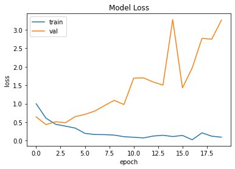

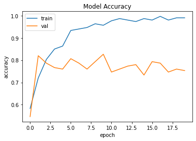

```python
# Plot the training and validation loss

plt.plot(history.history['loss'])
plt.plot(history.history['val_loss'])
plt.title('Model Loss')
plt.ylabel('loss')
plt.xlabel('epoch')
plt.legend(['train', 'val'], loc='upper left')
plt.show()

# Plot the training and validation accuracy

plt.plot(history.history['accuracy'])
plt.plot(history.history['val_accuracy'])
plt.title('Model Accuracy')
plt.ylabel('accuracy')
plt.xlabel('epoch')
plt.legend(['train', 'val'], loc='upper left')
plt.show()
```

**How does my model perform?**

The plots show that although the training loss has decreased and accuracy increased, as is desirable, validation accuracy has had marginal if any improvement in accuracy after just 2 epochs, and has had increasing loss scores.

The results indicate that the model is overfitting. I initially tried decreasing the learning rate, however this returned poor results and I returned to the initial learning rate of 0.001. I also tried several different batch sizes, with most succesful batch sizes being smaller ones.

The model may be corrected using data augmentation, such as in the next step. Alternatively, more data may be required to improve the model performance.

## **Task 2 (C Task) Analyse and improve the model**

### Task 2.1 Build an input pipeline for data augmentation

Build a data preprocessing pipeline to perform data augmentation. (You may use Keras ImageDataGenerator or write your own transformations.)

- Report the model performance with the pipeline added. How much performance gain have you achieved?
- Profile your input pipeline to identify the most time-consuming operation. What actions have you taken to address that slow operation? (*Hint: You may use a profiler such as the [TensorFlow Profiler](https://github.com/tensorflow/profiler).*)

### Task 2.2 Compare the performance under equal training time

You may notice that with your pipeline, the model performance improves, but at the cost of a longer training time per epoch. Is the additional training time well spent? Compare the dynamic of model performance (e.g., classification accuracy on the test data) with and without data augmentation, when equal training time is spent in the two scenarios.

### Task 2.3 Identifying model strength and weakness

Identify images that are incorrectly classified by your model. Do they share something in common? How do you plan to improve the model's performance on those images?

**Task 2.1 - Data Augmentation**

```python
# Choose parameters for data augmentation

data_augmentation = tf.keras.models.Sequential([
                              tf.keras.layers.experimental.preprocessing.RandomFlip("horizontal",
                                                                           input_shape=(200,200,3)),
                              tf.keras.layers.experimental.preprocessing.RandomRotation(0.1),
                              tf.keras.layers.experimental.preprocessing.RandomZoom(0.1),
])
```

```python
start2 = time.time()

aug_model = tf.keras.models.Sequential([
                                    data_augmentation,
                                    tf.keras.layers.Conv2D(16,(3,3),activation='relu', input_shape=(200,200,3)),
                                    tf.keras.layers.MaxPool2D(2,2),

                                    tf.keras.layers.Conv2D(32,(3,3),activation='relu'),
                                    tf.keras.layers.MaxPool2D(2,2),

                                    tf.keras.layers.Conv2D(64,(3,3),activation='relu'),
                                    tf.keras.layers.MaxPool2D(2,2),

                                    tf.keras.layers.Dropout(0.2),

                                    tf.keras.layers.Flatten(),

                                    tf.keras.layers.Dense(512,activation='relu'),

                                    tf.keras.layers.Dense(1,activation='sigmoid')

                                    ])

aug_model.compile(loss='binary_crossentropy',
              optimizer = tf.keras.optimizers.RMSprop(learning_rate=0.001),
              metrics=['accuracy'])

aug_history = aug_model.fit(train,
                      epochs=30,
                      batch_size=32,
                      validation_data=validation)

end2=time.time()
print("Run time is [s]", end2-start2)
```

```
Run time is [s] 545.1733658313751
```

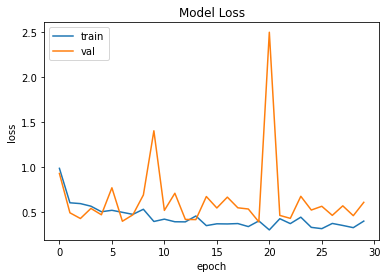

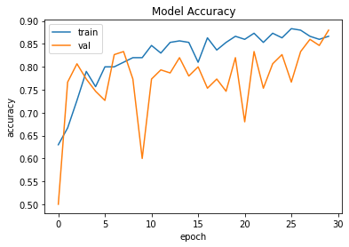

```python
# Plot the training and validation loss

plt.plot(aug_history.history['loss'])
plt.plot(aug_history.history['val_loss'])
plt.title('Model Loss')
plt.ylabel('loss')
plt.xlabel('epoch')
plt.legend(['train', 'val'], loc='upper left')
plt.show()

# Plot the training and validation accuracy

plt.plot(aug_history.history['accuracy'])
plt.plot(aug_history.history['val_accuracy'])
plt.title('Model Accuracy')
plt.ylabel('accuracy')
plt.xlabel('epoch')
plt.legend(['train', 'val'], loc='upper left')
plt.show()
```

**Task 2.3 Plot Incorrectly Classified Images**

```python
# View the labels on my test images

dir_path = '/content/gdrive/MyDrive/Datasetv4/Test'

for i in os.listdir(dir_path ):
  img=image.load_img(dir_path+'//'+i, target_size=(200,200))
  plt.imshow(img)
  plt.show()

  X = image.img_to_array(img)
  X=np.expand_dims(X, axis=0)
  images = np.vstack([X])
  val=aug_model.predict(images)
  if val ==0:
    print("Recycling")
  if val ==1:
    print("Rubbish")
```

```
Output hidden; open in https://colab.research.google.com to view.
```

Overfitting could be further reduced by adding more data. Now that the model runs effectively this is something I would be comfortable implementing.

## **Task 3 (D Task) Improve model generalisability across domains**

So far, you have used training and test images from the same source (via random data split). Now collect new test images from a different source. For example, you may take some photos yourself if you used downloaded images before. Otherwise, you may take new photos using a different mobile phone or against a different background.

Show sample images from the original test data and the newly collected test data. In what ways are they different?

Feed the new test data into your model. Report the performance change.

Improve your model so that it generalises better on unseen test images.

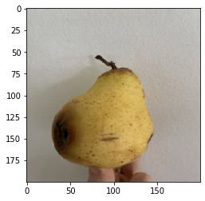

```
Rubbish
```

[figure not shown]

```
Recycling
```

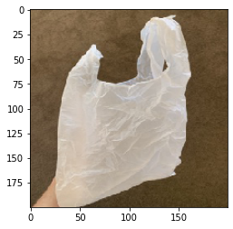

```
Rubbish
```

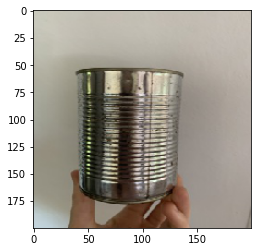

```
Recycling
```

[figure not shown]

```
Recycling
```

[figure not shown]

```
Recycling
```

[figure not shown]

```
Recycling
```

```python
# View the labels on my test images

dir_path2 = '/content/gdrive/MyDrive/Datasetv4/my_rubbish'

for i in os.listdir(dir_path2):
  img=image.load_img(dir_path2+'//'+i, target_size=(200,200))
  plt.imshow(img)
  plt.show()

  X = image.img_to_array(img)
  X=np.expand_dims(X, axis=0)
  images = np.vstack([X])
  val=model.predict(images)
  if val ==0:
    print("Recycling")
  if val ==1:
    print("Rubbish")
```

Due to my model making some mistake on test images, I was not optimisstic when feeding new data to the model that I had taken myself that included my hand in the picture and various noise in the background. I did attempt to take images on white background for a few, and kept noise in a few more. Surprisingly, the model has worked extremely well on these images with 100% accuracy correctly identifying three glass bottles and two tins as recycling and identifying organic waste and a plastic bag as rubbish. This showed that the model was robust enough to deal with some noise and variation, and is capabable of variation.

## **Task 4 (HD Task) Build a workable prototype**

Build a web/mobile app that people from your city council can use to determine what to recycle. Test your prototype with the target users and report their feedback.

Upload your code into a GitHub repository.

Create a short video presentation about your product.

```python
# Save the pre-trained model

aug_model.save('/content/gdrive/MyDrive/Datasetv4/my_model.h5')
recycleNetV2 = tf.keras.models.load_model('/content/gdrive/MyDrive/Datasetv4/my_model.h5')
```

```python
import gradio as gr
```

```python
#!pip install gradio
```

```python
def predict_image(img):
  img_4d=img.reshape(-1,200,200,3)
  prediction=recycleNetV2.predict(img_4d)[0]
  key_list = ["Recycling", "Rubbish"]
  return {validation.class_indices[key_list[i]]: float(prediction[i]) for i in range (2)}
```

```python
image=gr.inputs.Image(shape=(200,200))
label=gr.outputs.Label(num_top_classes=2)

gr.Interface(fn=predict_image, inputs=image, outputs=label, interpretation='default').launch(debug='True')
```

```
Colab notebook detected. This cell will run indefinitely so that you can see errors and logs. To turn off, set debug=False in launch().
Running on public URL: https://42274.gradio.app

This share link expires in 72 hours. For free permanent hosting, check out Spaces (https://huggingface.co/spaces)
```

[interactive chart not shown]

[output not shown]

```
Keyboard interruption in main thread... closing server.
```

```
(<fastapi.applications.FastAPI at 0x7fea91fc5f50>,
 'http://127.0.0.1:7860/',
 'https://42274.gradio.app')
```

**END OF ASSIGNMENT TWO**

```python
pip install nbconvert
```

```python
jupyter nbconvert --to html notebook.ipynb
```

[output not shown]